# BSAN2204

Lecture 11 Lecture

Predictive Analytics Report (A2) - Submission Info

Practical Demonstration (A3) - Briefing

## Finalising the Predictive Analytics Report (A2)

The *Predictive Analytics Report (A2)* is due next week!

Whilst the official due time is 4pm, we will accept submissions received up until **midnight (23:59pm)** before applying the late penalty (this time of submission also applies if you have received an extension on your submission date).

## Producing a high quality report

Students who did not do well in previous semesters tended fall into one of the following common pitfalls. Here is what to avoid!

- submitting the boiler plate course code examples without sufficient adaptation to individual interests
- providing only surface level insights from the analyses, or with only tangental level links to the broader contextual aims of the report
- formatting errors caused by mistakes in the use of R Markdown
- using overly overcomplicated code/convoluted methods of analysis that goes far beyond the scope established by the course content

## Overcomplicated code

A particularly noticeable trend from previous semesters is the inclusion of convoluted blocks of code echoed to the final report in areas where it is really not needed.

The following slides show some examples of “bad code” submitted by students in previous semesters. They do things like take steps to ensure the loaded file is the correct file, which is redundant for this course given there is only one file to choose from.

These can be easy mistakes to make as a result an over reliance on using AI when processing/analysing data or in the write up of your results/interpretations.

## Overcomplicated code (Example 1)

```r
# load the file placed in the working directory
load("MSD.RData")

# pick the largest data.frame in the environment (robust to object name differences)
objs <- mget(ls(), .GlobalEnv)
df_name <- names(sort(sapply(objs, function(x) if (is.data.frame(x)) nrow(x)*ncol(x) else 0),
                      decreasing = TRUE))[1]
msd_raw <- get(df_name)
```

## Overcomplicated code (Example 2)

```r
# Ensure the RData file is in the same folder as this .Rmd
load("MSD (1).RData")

# Detect the primary dataframe automatically (prefer 'msd' if present; else largest data.frame)
objs <- mget(ls())
df_names <- names(objs)[sapply(objs, is.data.frame)]
if ("msd" %in% df_names) {
  msd <- objs[["msd"]]
} else {
  sizes <- sapply(objs[df_names], nrow)
  msd <- objs[[ df_names[which.max(sizes)] ]]
}

# Replace NaN with NA ONLY in numeric columns (avoid coercing factors/characters)
msd <- msd %>% mutate(across(where(is.numeric), ~ifelse(is.nan(.), NA, .)))

# Ensure known categoricals are factors if present
for (nm in c("key", "mode", "time_signature")) {
  if (nm %in% names(msd) && !is.factor(msd[[nm]])) {
    msd[[nm]] <- factor(msd[[nm]])
  }
}
```

## Overcomplicated code (Example 3)

```r
load('MSD.RData')
# 2) If the main data object isn't named 'MSD', try to find a data.frame from the loaded objects
objs <- ls()
if (!exists("MSD")) {
  df_names <- Filter(function(x) is.data.frame(get(x)), objs)
  if (length(df_names) >= 1) {
    MSD <- get(df_names[1])
  } else {
    stop("No data.frame found in the loaded RData; expected an object named 'MSD'.")
  }
}

# 3) Basic structure (keep output tidy)
n_rows <- nrow(MSD); n_cols <- ncol(MSD)
cat("Full dataset size:", n_rows, "rows x", n_cols, "columns\n")
```

## Convoluted methods

Convoluted methods of analysis are often produced when the assignment briefing notes are used as the prompts to an AI model generating code. The methods taught in class (i.e., the boiler plate examples) are provided as a template for you to edit. Generating “new code” is not necessary! But using the code from class “as is” without any personal modifications does not show any evidence of your ability to adapt the code.

For example, the recommended method to produce descriptive statistics from the `MSD` is to use the `describe()` function from the `psych` package. The example below is shows a student using a building a custom function unnecessarily to manually calculating each individual statistic separately. This method is both error prone and using coding approach not taught in class.

## Convoluted methods (Example 1)

```r
## 3. Exploratory Analysis
# --- 3.1 Descriptive statistics for continuous (numeric) variables ---
num_cols <- names(msd_sample)[vapply(msd_sample, is.numeric, logical(1))]

if (length(num_cols) > 0) {
  desc <- data.frame(
    variable = num_cols,
    n        = vapply(msd_sample[num_cols], function(x) sum(!is.na(x)), integer(1)),
    mean     = vapply(msd_sample[num_cols], function(x) mean(x, na.rm = TRUE), numeric(1)),
    median   = vapply(msd_sample[num_cols], function(x) median(x, na.rm = TRUE), numeric(1)),
    sd       = vapply(msd_sample[num_cols], function(x) sd(x, na.rm = TRUE), numeric(1)),
    min      = vapply(msd_sample[num_cols], function(x) min(x, na.rm = TRUE), numeric(1)),
    max      = vapply(msd_sample[num_cols], function(x) max(x, na.rm = TRUE), numeric(1)),
    check.names = FALSE
  )
  # Round for readability
  is_num <- vapply(desc, is.numeric, logical(1))
  desc[is_num] <- lapply(desc[is_num], function(x) round(x, 2))
  print(desc)
} else {
  cat("No numeric columns found for continuous-variable summaries.\n")
}
```

## Using course code

The previous example generates a table of descriptive statistics, but the same table would be more appropriately (and easily) generated using the simple code given in class:

```r
varlist <- c("artist_familiarity", "artist_hotttnesss", "duration", "end_of_fade_in", "loudness",
             "song_hotttnesss", "start_of_fade_out","tempo", "year")
statslist <- c("n", "mean", "sd", "min", "max")
desc_stats <- psych::describe(MSD[, varlist])[, statslist]

knitr::kable(desc_stats, digits = 2) |>
kableExtra::kable_styling(font_size = 14)
```

|  | n | mean | sd | min | max |
| --- | --- | --- | --- | --- | --- |
| artist_familiarity | 997267 | 0.56 | 0.14 | 0.01 | 1.00 |
| artist_hotttnesss | 949460 | 0.40 | 0.09 | 0.01 | 1.08 |
| duration | 1000000 | 249.50 | 126.23 | 0.31 | 3034.91 |
| end_of_fade_in | 688733 | 1.19 | 3.93 | 0.06 | 1163.94 |
| loudness | 1000000 | -10.12 | 5.20 | -58.18 | 4.32 |
| song_hotttnesss | 457205 | 0.45 | 0.16 | 0.19 | 1.00 |
| start_of_fade_out | 1000000 | 240.63 | 124.08 | 0.31 | 3030.62 |
| tempo | 996770 | 124.29 | 34.39 | 7.36 | 302.30 |
| year | 515576 | 1998.40 | 10.93 | 1922.00 | 2011.00 |

Note: the above code mixes *analytical code* and code used to format the table. In your report, these should be **separated**, such that only the *analytical code* is echoed.

## *Adapting* course code

*Adapting* the course code implies making small/minor changes to the code in line with your own personal analytical objectives.

Examples of this could simply include varying the naming of the objects you create, making different decisions about the formats of the outputs generated, and different (justified) decisions about the list of variables used in your analysis.

## Echoing only analytical code

```r
varlist <- c("artist_familiarity", "artist_hotttnesss", "duration", "end_of_fade_in", "loudness",
             "song_hotttnesss", "start_of_fade_out","tempo", "year")
statslist <- c("n", "mean", "sd", "min", "max")
desc_stats <- psych::describe(MSD[, varlist])[, statslist]
```

|  | n | mean | sd | min | max |
| --- | --- | --- | --- | --- | --- |
| artist_familiarity | 997267 | 0.56 | 0.14 | 0.01 | 1.00 |
| artist_hotttnesss | 949460 | 0.40 | 0.09 | 0.01 | 1.08 |
| duration | 1000000 | 249.50 | 126.23 | 0.31 | 3034.91 |
| end_of_fade_in | 688733 | 1.19 | 3.93 | 0.06 | 1163.94 |
| loudness | 1000000 | -10.12 | 5.20 | -58.18 | 4.32 |
| song_hotttnesss | 457205 | 0.45 | 0.16 | 0.19 | 1.00 |
| start_of_fade_out | 1000000 | 240.63 | 124.08 | 0.31 | 3030.62 |
| tempo | 996770 | 124.29 | 34.39 | 7.36 | 302.30 |
| year | 515576 | 1998.40 | 10.93 | 1922.00 | 2011.00 |

Note here that the `knitr` and `kableExtra` package functions which control the aesthetics of the table are not echoed to this slide, only the analytical steps to select variables, statistics and the computation of the statistics are echoed.

## Do not include comments!

Comments are useful sign posts for **the analyst** but should not be included in code that is output to a rendered report document.

Comments are useful to retain inside code chunks which are not output to the document. You treat them more like “notes to self” rather than narrative text for others to read. In the context of a R Markdown or Quarto document, the use of comments becomes particularly redundant given the main purpose of using these formats is to provide rich text commentary both about your code and the outputs it generates.

[figure not shown]

## Do not include `R` console output

In class, we regularly checked what the output of functions in the console to check/interpret our analysis before we decided to included those lines of code in the report (usually by piping that output to functions which reformatted the outputs for presentation).

The areas where students most commonly make the mistake of including raw ouptuts is in their descriptive analytics section. In class, we spent time looking at the outputs of `str()` and `summary()` in the console, but these were just tutorial exercises! For the *Practical Demonstration (A3)* it is *critical* that you do not include raw `R` console output.

[figure not shown]

## What *is* “raw `R` console output”?

In the context of BSAN2204, anything other than a plot or formatted HTML table is considered “raw console output” (i.e., anything that would normally appear as text in the console). For example, the `class()` function, if just run on its own will generate raw console output.

```r
class(MSD)
```

```
[1] "data.frame"
```

This output would look far better in a report to render using **inline code**:

```
The data is of the type `r class(MSD)` and it contains the following variables `r names(MSD)`.
```

The data is of the type data.frame and it contains the following variables artist_name, artist_7digitalid, artist_familiarity, artist_hotttnesss, duration, end_of_fade_in, key, loudness, mode, release, release_7digitalid, song_hotttnesss, start_of_fade_out, tempo, time_signature, title, track_7digitalid, year.

## `R` console output is *for your eyes only*!

In your *Predicative Analytics Report (A2)* you should only have **one** table of regression results in the *predictive analytics* section generated using `modelsummary()`, or a similar regression tabulation package.

Do not include the raw outputs from the `summary()` command. Instead, assign tbe output from `summary()` to model objects, and format them into a single table using `modelsummary()`.

## Inclusion of extra methods

It important to ensure you demonstrate your ability to use methods of business analytics taught in class. Including methods of business analytics not taught in BSAN2204 can be used, although are unlikely to contribute to achieving a higher grade unless they are well justified extensions. That is, alternate methods should only be used where they genuinely *extend* the analysis rather than replace them.

Pay close attention to what is taught in lectures/tutorials, and **do not** rely on examples of assignments submitted in other courses or previous semesters of this course (as requirements have changed!).

For example, we did not teach the use of correlation analysis in 2026, so we do not expect to see any outputs or discussion in your report relating to this method!

## Predictive Analytics Reports (A2) - FAQs

Q: Should I summarise the full MSD or my subset in the Exploratory Analysis section?

- This does not matter too much. It is OK to summarise the full MSD (rather than your training data) in the Exploratory Analysis section, or your subset. It is essential, however, that you only use your training and test data splits in the predictive analytics section.

## Predictive Analytics Reports (A2) - FAQs

Q: Should I use single or multiple imputation as part of my model validation process?

- We have taught the use of single imputation in this context, although in practice analysts typically would use multiple imputation. Multiple imputation in this context however typically involves the use of programming concepts not yet taught in the BSAN major (flow control, loops, etc.), hence we recommend using the simpler approach.

## Predictive Analytics Reports (A2) - FAQs

Q: Should I (can I?) include artist hotness or artist familiarity in my models?

- Yes, but you need to recognise that values for these variables may not be reliably available for prediction. If you use these variables, you need to demonstrate that you understand how to use them appropriately in prediction.

Refer to the discussions had during previous lectures on this point!

## Predictive Analytics Reports (A2) - FAQs

Q: Should I summarise all continuous variables in my descriptive statistics?

- “Summarise” yes, but it is not necessary to go into descriptive detail for each single variable, or every possible bivariate relationship. It is important to broadly summarise the entire dataset at least once for the purpose of communicating to your audience about what is contained in the dataset. This should include listing what variables are in the data, and providing an indication of what variables will *not* be included later in your analysis.

## Predictive Analytics Reports (A2) - FAQs

Q: How many visualisations should I include?

- The report must include at least **one each** of the following types of data visualisations: a univariate graph, and a bivariate graph. Advanced reports will make design choices that maximise the impact of their visualisations.

Multiple graphs can be combined and reported in muliplot objects (i.e., using methods like `mfrow()` or `facet_wrap()`).

## Predictive Analytics Reports (A2) - FAQs

Q: How many words should I write?

- There is no word limit. This does NOT mean you should write nothing at all! You should aim to be **concise** in your writing, whilst still ensuring you give you interpret your analysis.

The **Introduction** should overview of the project based on your own background research. This will take *several paragraphs*.

The **Recommendations** summarises what insights have been drawn from the data, provide some concluding remarks about the potential usefulness of the analysis should be provided, as well as highlighting any potential limitations of the analysis. This will also take at least *several paragraphs*.

Elsewhere in the report (**analytical sections**), *brief sentences* of narrative text needs to include text to describe and document your analysis of the data. This text should concisely describe the steps being taken in your `R` code and concisely describe any outputs that included in the report.

## Practical Demonstration (A3)

The *Practical Demonstration (A3)* is an observed form of assessment. Students will be given access to a unique dataset on BlackBoard at the start of the assessment time and a briefing written in the form of an email from a hypothetical business analytics colleague/client asking for “request for a quick data summary and analysis”.

You will receive this email as a real email at the start of the working time during the assessment. It will be posted as announcement on Blackboard.

## Output oriented task

The task requires students to produce a minimally formatted HTML file (`*.html`) report using R Markdown under observation that includes descriptive statistics, visualisations and a regression model with concise interpretations using the data provided. Students must complete their response to the client briefing under observation within the time constraint of an examination setting.

Given this output orientation, there is less emphasis placed on your processes to produce the output. A large part of the task will in practice require you to individually and independently troubleshoot issues encountered in your analysis, and during the process of rendering the report to a `.html` file.

## Time limited task

Underpinned by the principles of authentic assessment, this task gives students an opportunity to be a *business analyst* responding to an urgent email request from a manager. Students receive a previously unseen R dataset and a workplace-style briefing and must deliver a concise data summary and analytical report that informs a business decision for consideration by a client.

The task simulates the type of evidence-based analysis commonly undertaken in professional analytics roles. It is completed individually under invigilated exam conditions, requiring students to independently demonstrate their analytical capabilities while working within realistic workplace time constraints.

## Using template code

This assessment builds directly on *Predictive Analytics Report (A2)* and the sequence of scaffolded learning activities throughout the semester. By this point you have progressively developed and practise the required skills.

You can and should adapt the code used in A2 and the tutorials as to prepare the data you are given, produce visualisations, do predictive modelling and build a professional report document. By the time you undertake the practical demonstration, you should have rehearsed the analytics workflow, enabling you to transfer these skills to an unfamiliar dataset under exam conditions.

## Simulated work setting

To mirror the tools and challenges of a professional work setting, students will be permitted to access the Internet and use AI tools during the assessment time to assist in the completion of the assessment. This assessment evaluates practical skills related to data exploration and predictive analytics, adaptability, and proficiency in using real-world tools under time constraints.

There are no restrictions on which tools you use. You can (read: **you should**) use your Predictive Analytics Report (A2) `*.Rmd` file as a *template* for your Practical Demonstration (A3). The data you will be provided differs, however the expected structure of your report remains the same (with the exception of not expecting the use of model validation or missing data imputation).

## Practical Demonstration (A3) - Timetabling

**Date:** Tuesday 17 Nov 2026

**Arrive/setup:** 2:50 PM (10 minutes)

**Working time:** 3:00 PM - 5:00 PM (2 hours)

**Location(s):** See next slide

If you have an approved Alternative Exam Arrangements (AEA) please monitor your inbox as you will be contacted individually with separate information regarding your specific arrangements.

## Practical Demonstration (A3) - Location(s)

**Room 1 (odds)**:

If your 8 digit student ID ends in an ODD number, e.g., 1234567**1** attend:

39A-208 – General Purpose North (39A), Room 208

**Room 2 (evens)**:

If your 8 digit student ID ends in an EVEN number, e.g., 1234567**2** attend:

50-S201 – Hawken Engineering (50), Room S201

**It is essential you attend your allocated session** in order to ensure rooms do not exceed their available seating capacity.

Do not confuse your student **username** (s1234567) with your **8 digit student ID** (12345678).

## 8 digit student number

Your student ID is an 8-digit `numeric` value, while your student username is a `character` string consisting of the letter “s” followed by the first 7 digits of your student ID. The 8th digit, the one you need to check to determine the location of your *Practical Demonstration (A3)*, is omitted from your username, therefore:

**Make sure you refer to your student ID number** (not your student username)!

[figure not shown]

```r
class(47654321)
```

```
[1] "numeric"
```

```r
class("s4765432")
```

```
[1] "character"
```

## Assessment locations

### (IDs ending in a ODD number)

39A-208 – General Purpose North (39A), Room 208

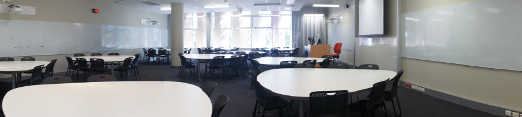

There are **limited** power sockets available in this room (although *some* are available). Please ensure you have a fully charged laptop on the day to complete the assessment.

If your 8 digit student ID ends in **1, 3, 5, 7 or 9**, attend this room.

Do not confuse your student **username** with your **8 digit student ID**.

## Assessment locations

### (IDs ending in a EVEN number)

50-S201 – Hawken Engineering (50), Room S201

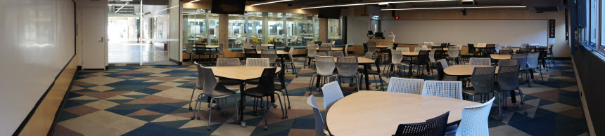

There are **limited** power sockets available in this room (although *some* are available). Please ensure you have a fully charged laptop on the day to complete the assessment.

If your 8 digit student ID ends in **0, 2, 4, 6 or 8**, attend this room.

Do not confuse your student **username** with your **8 digit student ID**.

## Charge your battery!

[figure not shown]

Reminder: Neither of the rooms have power points on the tables (but they are available on the walls). Please ensure you bring your laptop **fully charged**, or to bring a suitable power bank as a back up. If you have concerns about your laptop, arrange to borrow one from the library. See: https://web.library.uq.edu.au/library-and-student-it-help/using-library-devices/laptop-loans

## Identity Verified Assessment

**Students must bring their student ID card**.

[figure not shown]

Doors will open at 10 minutes before the assessment start time. During this initial 10 minute set up time, students should open and power on their laptops and place their student ID card on their desk for checking.

During the assessment time, course staff will progressively move through the room to check and verify the identity of each student present.

## What is permitted?

To mirror the tools and challenges of a professional work setting, students will be permitted to access the Internet and use AI tools during the assessment time to assist in the completion of the assessment.

This assessment evaluates practical skills related to data exploration and predictive analytics, adaptability, and proficiency in using real-world tools under time constraints.

## On the use of AI

As with any assessment, an over reliance upon the use of AI may lead you astray into analysis methods or code which is not covered BSAN2204. An implicit expectation is that students might use AI as part of their workflow, for example to troubleshoot their code. What we expect would be required by most students in order to stay within the assessment guidelines would be interactive use of a basic AI chat interfaces (as opposed to the use of advanced embedded AI) combined with manual editing/coding of the outputs.

Recall the focus of this assessment is primarily your **output**, *not your process*. With this in mind, the task is designed such that it requires careful consideration of the context and understanding of the required output. Experience shows that simple AI tools tend to overextend beyond the scope of the assessment when not carefully guided, as such careful guidance (of AI tools) can only be given by a student with a strong grasp of the course concepts.

## What is NOT permitted?

Note that this is an **individual assessment**. You must not communicate during the assessment period.

Non-compliance may constitute misconduct and may be referred to the Academic Registrar as per the [Student Integrity and Misconduct Policy](https://policies.uq.edu.au/document/view-current.php?id=149).

## Context of the assessment

The context of the assessment, the mock email correspondence and dataset will be posted on Blackboard during the first 10 minutes prior to the assessment start time. It will be dataset you *you have not seen before*.

Your task in the assessment will be to practically demonstrate your ability to apply the following course content:

- reading in data to R
- descriptive statistics
- data visualisation
- predictive analytics (regression, not including missing data analysis or model validation)
- HTML report generation using R Markdown (or Quarto)

## Revision Topics

The topics listed on the previous slide may be revised in the final week lecture (if there is appetite).

The final tutorial sessions will run as revision sessions. Your tutor will revisit the tutorial content covered earlier in the semester and to practice applying the relevant methods (reading in data, descriptive statistics, visualisations, and regression), and readying a template `.Rmd` file for use in the *Practical Demonstration (A3)*

## Readying a template `.Rmd` file

The *Predictive Analytics Report (A2)*, can (and should) be used as template files for the *Practical Demonstration (A3)*. Adapting a previously written report as a template for a future report is commonplace in industry.

These reports, particularly if document defaults are properly set in their YAML, will serve you well both for the final assignment in BSAN2204 as well as assignments in upcoming BSAN courses in your degree.

## File and variable names

The main things which differ between the data used for Predictive Analytics Report (A2) (i.e., the `MSD`) is the **name** of the data file you will be provided, and the **names** of the variables (columns) within the new data file.

One useful way to prepare (rehearse) for the *Practical Demonstration (A3)* is to practice re-rendering your existing `.Rmd` file, but with a renamed version of the `MSD.Rdata` file.

A pitfall encountered by some students in previous semesters was hitting a roadblock when rendering their *Practical Demonstration (A3)* `.html` due to basic issues such as their new `.Rdata` file simply not being in the correct working directory or incorrectly referring to the filename (i.e., rendering would fail at the `load()` command).

## Submission Guidelines

Submit your report using the *Practical Demonstration (A3)* submission link on the BSAN2204 - Methods of Business Analytics Blackboard site located in the Assessment section. The submission must be received during the time frame of your allocated session to complete the assessment.

There is no word or lines of code limit for this assessment, but the submission must not include more than:

- 1 table of descriptive statistics;
- 4 visualisations (note: a multi-plot visualisation counts as 1);
- 1 table of predictive analytics.

The report should be submitted as a `.html` file generated using R Markdown. Reports submitted in other formats (e.g., Word .doc) will be accepted, but will receive a low grade on the document formatting criteria.

Thank you!

[figure not shown]